# Proyecto

2023-06-14

```r
con <- DBI::dbConnect(
  RPostgres::Postgres(),
  host = Sys.getenv("DB_HOST"),
  port = Sys.getenv("DB_PORT"),
  user = Sys.getenv("DB_USER"),
  password = Sys.getenv("DB_PASS"),
  dbname = Sys.getenv("DB_NAME")
)
```

```r
# Obtener nombres de las tablas de la base de datos
tablas <- DBI::dbListTables(con)

# Obtener las variables de las tablas
for (i in tablas){
  cant <- dbGetQuery(con, paste("Select count(*) from", i ))[1,1]
  print(paste("Tabla: ", i))
  print(paste("Cantidad de datos: ", cant))
  print("Varibales de la tabla:")
  print(DBI::dbListFields(con, name = i))
  cat("\n", "\n")
}
```

```
## [1] "Tabla:  d_date"
## [1] "Cantidad de datos:  3652"
## [1] "Varibales de la tabla:"
##  [1] "id_fecha"               "date_actual"            "epoch"
##  [4] "day_suffix"             "day_name"               "day_of_week"
##  [7] "day_of_month"           "day_of_quarter"         "day_of_year"
## [10] "week_of_month"          "week_of_year"           "week_of_year_iso"
## [13] "month_actual"           "month_name"             "month_name_abbreviated"
## [16] "quarter_actual"         "quarter_name"           "year_actual"
## [19] "first_day_of_week"      "last_day_of_week"       "first_day_of_month"
## [22] "last_day_of_month"      "first_day_of_quarter"   "last_day_of_quarter"
## [25] "first_day_of_year"      "last_day_of_year"       "mmyyyy"
## [28] "mmddyyyy"               "weekend_indr"           "feriado"
##
##
```

[output cut: 22 more lines]

```r
d_sensores <- DBI::dbGetQuery(
  con,
  "SELECT * FROM d_sensores"
  )
mvd_map <- load_geouy("Barrios")
mvd_map_fixed <- st_make_valid(st_transform(mvd_map, crs = 4326))
puntos_sensores <- d_sensores %>%
  select(latitud, longitud) %>%
  mutate(puntos_transformados = transformarCoord(latitud, longitud, mvd_map))
capaSemafotos <- st_read(here::here("v_int_semaforos", "v_int_semaforos.shp"))
```

```r
# Crear una paleta de colores discreta, usando una funcion que indica como colorear para evitar
# que queden
colores <- colorFactor(
  palette = "Set1",
  domain = nacol(mvd_map_fixed)
)

# Crear el mapa interactivo con una capa de polígonos
(
  map <- leaflet() %>%
  addTiles() %>%
  addPolygons(
    data=mvd_map_fixed,
    weight = 5,
    opacity = 0.5,
    fill = TRUE,
    fillColor = ~colores(nacol(mvd_map_fixed)),
    popup = NULL,
    popupOptions = NULL,
    label = ~stringr::str_to_title(nombbarr)
  ) %>%
  addMarkers(
    data = d_sensores,
    lat = ~latitud,
    lng = ~longitud,
    label = ~paste(dsc_avenida, " - ", dsc_int_anterior, " - ", dsc_int_siguiente)
  ) %>%
  addCircleMarkers(
    data = st_transform(capaSemafotos, crs = 4326),
    color = "red",
    radius = 3)
)
```

[interactive chart not shown]

# Preguntas de Investigación

1. ¿Influye el barrio con la velocidad a la que van los vehículos?
2. ¿Existe alguna correlación entre el volumen de tráfico y la velocidad promedio en las avenidas de Montevideo?
3. ¿Existen diferencias en el volumen de tráfico y la velocidad promedio entre días laborales y fines de semana?
4. ¿Cuáles son las avenidas con los marzores promedios de velocidad en Montevideo?
5. **nueva** ¿Como afecta la presencia de semaforo a los indicadores de volumen y velocidad?

## 1 - ¿Influye el barrio con la velocidad a la que van los vehículos?

```r
(
  velocidadxBarrioMax <- DBI::dbGetQuery(
    con,
    "
    SELECT
      d_sensores.barrio,
      MAX(fct_registros.velocidad) AS max_velocidad
    FROM fct_registros
    LEFT JOIN d_sensores ON fct_registros.id_detector = d_sensores.id_detector
    GROUP BY d_sensores.barrio
    "
  )

)
```

```
##                       barrio max_velocidad
## 1                     AGUADA           142
## 2                  ATAHUALPA           144
## 3                  BELVEDERE           143
## 4             BRAZO ORIENTAL           144
## 5                      BUCEO           144
## 6      CAPURRO - BELLA VISTA           144
## 7                   CARRASCO           143
## 8             CARRASCO NORTE           144
## 9                     CENTRO           143
## 10                   CERRITO            98
## 11                     CERRO           128
## 12   COLON CENTRO Y NOROESTE           142
## 13              CONCILIACION           142
## 14                    CORDON           144
```

[output cut: 29 more lines]

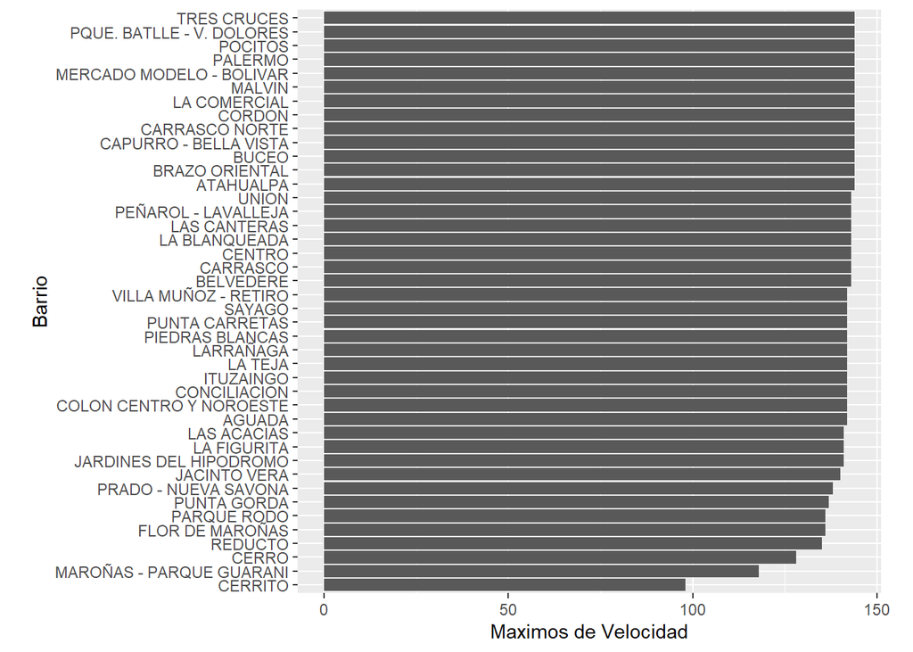

```r
velocidadxBarrioMax %>%
  filter(barrio != 'NA') %>%
  ggplot(aes(y = max_velocidad,
             x= fct_reorder(barrio, max_velocidad)
        )
    ) +
  geom_col() +
  coord_flip() +
  theme(
    aspect.ratio = 1,
  ) +
  scale_x_discrete(name = "Barrio") +
  scale_y_continuous(name = "Maximos de Velocidad")
```

```r
(
  mvd_map_velocidad_media <- mvd_map %>%
    left_join(velocidadxBarrioMax,
              by = c("nombbarr" = "barrio"))
)
```

```
## Simple feature collection with 62 features and 5 fields
## Geometry type: MULTIPOLYGON
## Dimension:     XY
## Bounding box:  xmin: 551982.7 ymin: 6133499 xmax: 589227.2 ymax: 6159810
## Projected CRS: WGS 84 / UTM zone 21S
## First 10 features:
##               gml_id area_km                nombbarr nrobarrio max_velocidad
## 1   barrios_ine_uy.1   2.111            CIUDAD VIEJA         1            NA
## 2  barrios_ine_uy.55  31.795 COLON SURESTE - ABAYUBA        58            NA
## 3  barrios_ine_uy.53   2.783  TRES OMBUES - VICTORIA        56            NA
## 4  barrios_ine_uy.45   0.784           LA BLANQUEADA        47           143
## 5  barrios_ine_uy.49   1.873          BRAZO ORIENTAL        51           144
## 6  barrios_ine_uy.50   2.612                  SAYAGO        52           142
## 7  barrios_ine_uy.51   5.074            CONCILIACION        53           142
## 8  barrios_ine_uy.52   6.790             NUEVO PARIS        55            NA
## 9  barrios_ine_uy.54  75.233        PASO DE LA ARENA        57            NA
## 10  barrios_ine_uy.2   1.297                  CENTRO         2           143
##                          the_geom
## 1  MULTIPOLYGON (((573146.3 61...
## 2  MULTIPOLYGON (((571329.3 61...
## 3  MULTIPOLYGON (((569357.2 61...
## 4  MULTIPOLYGON (((578073.8 61...
## 5  MULTIPOLYGON (((574736 6140...
## 6  MULTIPOLYGON (((571272.1 61...
## 7  MULTIPOLYGON (((567929.4 61...
## 8  MULTIPOLYGON (((567972.1 61...
## 9  MULTIPOLYGON (((558741.1 61...
## 10 MULTIPOLYGON (((574497.2 61...
```

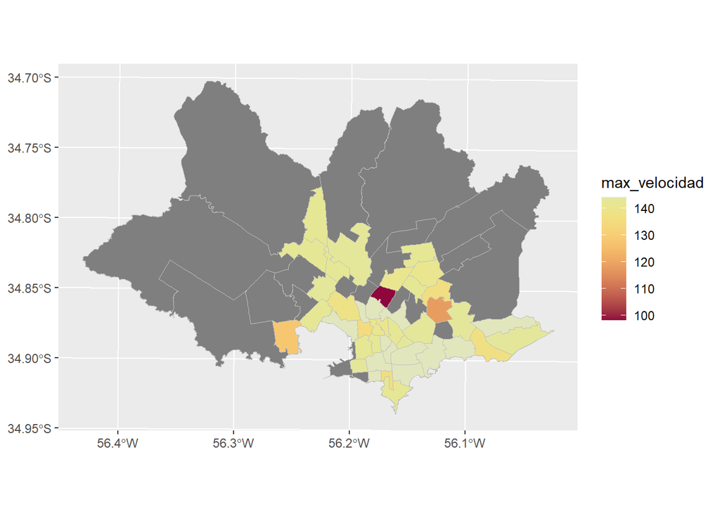

```r
mvd_map_velocidad_media %>%
  ggplot(aes(fill = max_velocidad)) +
  geom_sf(colour = "grey75", size = 0.07) +
  scale_fill_paletteer_c(palette = "grDevices::Heat")
```

## 4 - ¿Cuáles son las avenidas con los mayores promedios de velocidad en Montevideo?

Para responder a esta pregunta, necesito determinar en que intervalo de tiempo voy a considerar el promedio. Ahora como primer acercamiento a los datos, me interesa determinar el promedio de velocidades por radar (cual va a estar en una determinada avenida), en el periodo de *marzo 2023*.

```r
(
  promedios_velocidad <- DBI::dbGetQuery(
    con,
    "
    WITH query_name1  AS (
      SELECT
        fct_registros.velocidad,
        d_sensores.dsc_avenida
      FROM fct_registros
      LEFT JOIN
        d_sensores
        ON
          fct_registros.id_detector = d_sensores.id_detector

    )
    SELECT COUNT(velocidad) WHERE velocidad >60
    GROUP BY d_sensores.dsc_avenida
    FROM query_name1

    "
  )
)
```

[output not shown]

```r
(
cantMarzorLimite60 <- promedios_velocidad_marzo23 %>%
  select(dsc_avenida,velocidad) %>%
  group_by(dsc_avenida) %>%
  summarise(
    cantMayorALimite = sum(velocidad > 60)
  ) %>% arrange(desc(cantMayorALimite))
)
```

[output not shown]

```r
promedios_velocidad_marzo23 %>%
  group_by(dsc_avenida) %>%
  summarise(velocidad_promedio = round(mean(velocidad), 3)) %>%
  filter(velocidad_promedio > 40) %>%
  ggplot() +
  geom_col(
    aes(x = velocidad_promedio,
        y = reorder(dsc_avenida, velocidad_promedio)
        )
    ) +
  scale_x_continuous(name = "Velocidad promedio") +
  scale_y_discrete(name = "Calles")
```

[output not shown]

```r
div <- function(cantMayorALimite) {
  paste0("<div>", cantMayorALimite, "</div>")
}


#Clasifica
getColor <- function(cantMayorALimite) {
  ifelse(cantMayorALimite <= 100, "green", ifelse(cantMayorALimite <= 1000, "orange", "red"))
}


icons <- awesomeIcons(
  icon = 'ios-close',
  iconColor = 'black',
  library = 'ion',
  markerColor = getColor(cantMarzorLimite60$cantMayorALimite)
)

leaflet(cantMarzorLimite60) %>%
  addTiles() %>%
  addAwesomeMarkers(lat = ~latitud, lng = ~longitud, icon = icons,
             label = ~dsc_avenida,
             popup = div(cantMarzorLimite60$cantMayorALimite)
             )
```

[output not shown]

## 2.¿Existe alguna correlación entre el volumen de tráfico y la velocidad promedio en las avenidas de Montevideo?

```r
(
  promediosMarzo23 <- DBI::dbGetQuery(
    con,
    "
      WITH velocidad_volumen_enero_2023 AS (
  SELECT
    fct_registros.velocidad,
    fct_registros.volume,
    d_sensores.dsc_avenida,
    d_date.year_actual
  FROM fct_registros
  LEFT JOIN d_sensores ON fct_registros.id_detector = d_sensores.id_detector
  LEFT JOIN d_date ON fct_registros.id_fecha = d_date.id_fecha
),
promedios_marzo_23 AS (
  SELECT
    dsc_avenida,
    year_actual,
    AVG(velocidad) AS velocidad_media,
    AVG(volume) AS volumen_media
  FROM velocidad_volumen_enero_2023
  GROUP BY dsc_avenida, year_actual
)
SELECT *
FROM promedios_marzo_23

    "
  )
)
```

```
##              dsc_avenida year_actual velocidad_media volumen_media
## 1            18 de Julio        2021       24.071051     12.230605
## 2            18 de Julio        2022       23.467925     11.373050
## 3            18 de Julio        2023       26.192891     12.479298
## 4          20 de Febrero        2021       24.214030     20.272490
## 5          20 de Febrero        2022       21.377410      9.608030
## 6        21 de Setiembre        2021       31.805869     22.290580
## 7        21 de Setiembre        2022       31.882089     22.640992
## 8        21 de Setiembre        2023       31.099833     21.001854
## 9            26 de Marzo        2021       31.526470     16.361265
## 10           26 de Marzo        2022       26.468030     13.908398
## 11           26 de Marzo        2023       31.418430     13.230130
## 12          8 de Octubre        2021       33.937162     17.744157
## 13          8 de Octubre        2022       34.230350     16.055129
## 14          8 de Octubre        2023       35.947792     16.810154
```

[output cut: 256 more lines]

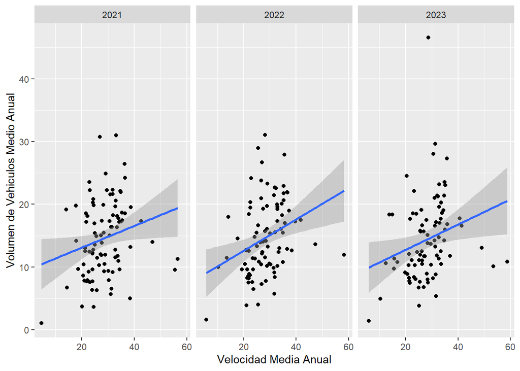

```r
promediosMarzo23 %>%
  ggplot(
    aes(
      x = velocidad_media,
      y = volumen_media
    )
  ) +
  geom_point() +
  facet_wrap(~year_actual) +
  scale_x_continuous(name = "Velocidad Media Anual") +
  scale_y_continuous(name = "Volumen de Vehiculos Medio Anual") +
  geom_smooth(method = lm)
```

```r
promediosMarzo23 %>% group_by(year_actual) %>%
  summarise(
    correlacion = cor(velocidad_media, volumen_media)
  )
```

```
## # A tibble: 3 × 2
##   year_actual correlacion
##         <int>       <dbl>
## 1        2021       0.222
## 2        2022       0.313
## 3        2023       0.248
```